# 11-Tarea

1. En este ejercicio usaremos los datos *threept*, éstos corresponden a lanzamientos para encestar canastas de 3 puntos, las variables *r* y *ángulo* indican la posición desde donde se lanzó el balón, siendo *r* la distancia entre el jugador y la canasta y *angle* el ángulo entre ellos.

```r
threept <- read.csv("threept.csv")
head(threept)
```

```
##               .id period                time team etype
## 1 20081028.PORLAL      1 2010-02-02 00:04:06  LAL  shot
## 2 20081028.PORLAL      1 2010-02-02 00:03:34  LAL  shot
## 3 20081028.PORLAL      1 2010-02-02 00:01:31  LAL  shot
## 4 20081028.PORLAL      1 2010-02-02 00:00:00  LAL  shot
## 5 20081028.PORLAL      2 2010-02-02 00:06:32  LAL  shot
## 6 20081028.PORLAL      2 2010-02-02 00:01:58  LAL  shot
##                player points result          x         y        r
## 1 Vladimir Radmanovic     NA missed  0.7527903  5.738697 24.91706
## 2          Lamar Odom     NA missed 40.5238888 25.705532 30.02941
## 3        Trevor Ariza      3   made 45.6325516 17.408215 26.99534
## 4       Sasha Vujacic     NA missed 37.4890770 30.476971 32.93665
## 5        Trevor Ariza      3   made 42.8808397 24.011976 29.93826
## 6 Vladimir Radmanovic      3   made  7.9488106 28.036978 32.81486
##       angle
## 1 166.68456
## 2  58.87170
## 3  40.15519
## 4  67.71680
## 5  53.32629
## 6 121.30662
```

- ¿La posición en la cancha influye en la probabilidad de éxito (encestar)? Piensa en una manera gráfica de visualizar esta pregunta y pruebala usando inferencia gráfica.

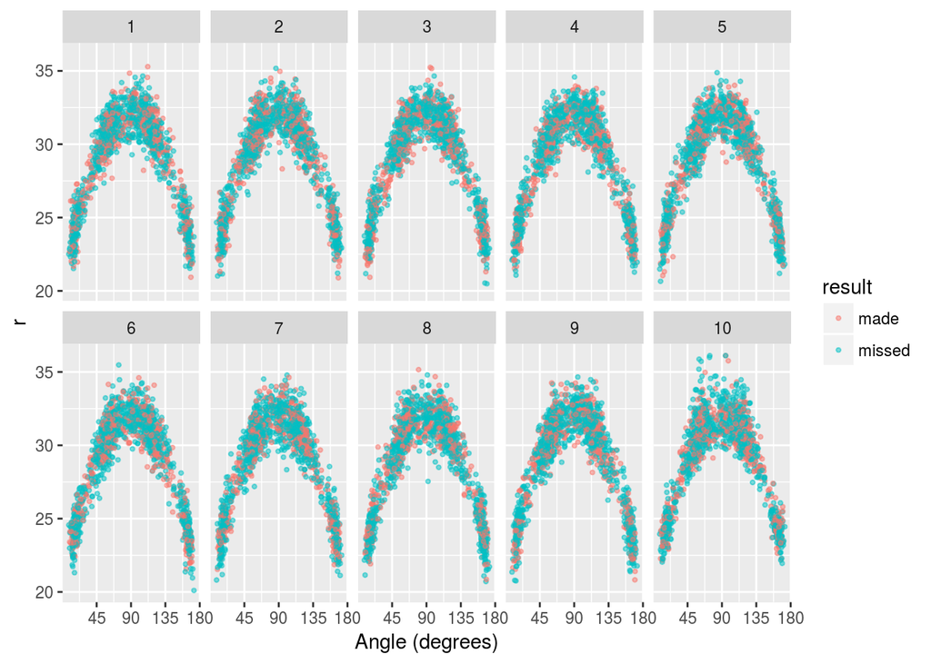

```r
# Inference
library(ggplot2)
library(nullabor)
fit <- lm(r ~ poly(angle, 2), data = threept)
n <- 10
# matriz de covariables
X <- model.matrix(r ~ poly(angle, 2), threept)
n_obs <- nrow(X)
sims <- rep(X %*% coef(fit), n - 1) + rnorm((n - 1) * n_obs, mean = 0, sd = 1)

threept_3<- data.frame(
    angle = rep(threept$angle, n), # el valor de x (ángulo) para cada panel
    r = c(threept$r, sims),  # distancias simuladas y observadas
    result=(threept$result),
    id = rep(sample(1:n, size = n), each = n_obs)) # id aleatorio para esconder los datos

ggplot(threept_3, aes(x = angle , y = r)) +
    geom_point(aes(color=result),alpha = 0.5, size = 0.8) +
    scale_x_continuous("Angle (degrees)",
        breaks = c(0, 45, 90, 135, 180)) +
    facet_wrap(~ id, nrow = 2)
```

2. Se busca estudiar el efecto de pesticidas en el control de cucarachas en departamentos urbanos. Se realiza un experimento deonde se dividen los departamentos en grupo de tratamiento (160 deptos.) y grupo de control (104 deptos.). En cada departamento se mide el número de cucarachas atrapadas $y_i$ en un conjunto de trampas. Distintos departamentos tuvieron trampas un número distinto de días, y denotamos por $u_i$ el número de días-trampa en el i-ésimo departamento. Se propone el siguiente modelo:
   $$y_i \sim Poisson(u_i,exp(X\beta))$$
   donde X reprersenta variables explicativas (predictores), en este caso, consisten en el nivel de cucarachas antes del tratamiento (roach1), una variable binaria indicando si se aplica insecticida en el departamento (treatment) y una variable binaria indicando si el edificio es de personas mayor (senior). En R el modelo se ajusta como sigue:

```r
roachdata <- read.csv("roachdata.csv", stringsAsFactors = FALSE)
glm_1 <- glm(y ~ roach1 + treatment + senior, family = poisson,
  offset = exposure2, data = roachdata)
```

- ¿Qué tan bien se ajusta el modelo a los datos? Para responder esta pregunta crea 19 datos simulados y grafica un histograma de los datos junto con los datos verdaderos. Para simular del modelo puedes usar el siguiente código:

```r
n <- nrow(roachdata)
X <- model.matrix(~ roach1 + treatment + senior, family = poisson,
  data = roachdata)
y_hat <- roachdata$exposure2 * exp(X %*% coef(glm_1))
y_rep <- rpois(n, y_hat)
```

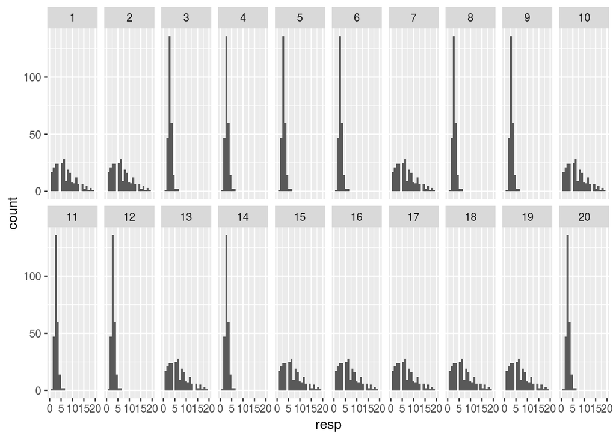

```r
n_obs<-nrow(roachdata)
n<-20
yy_3 <- data.frame(
    resp= c(predict(glm_1), y_rep),
    id = rep(sample(1:n, size = n), each = n_obs))

ggplot(data=yy_3,aes(x=resp))+geom_histogram(binwidth = .9)+ facet_wrap(~ id, nrow = 2)+scale_x_continuous(limits = c(0,20))
```

- ¿En que se diferencían los datos observados de los simulados?

en qu los simulados estan mejor distribuidos que los verdaderso ya que se ven sesgados.

3. Neurocientíficos cognitivos investigan que áreas del cerebro se activan durante una tarea específica. Es común que los investigadores observen que un área particular del cerebro se encuentra activa y a partir de ello infieran que se está llevando a cabo una función cognitiva particuar. En un artículo Poldrack notó que esas inferencias no tenían mucho sustento, y recomendó que se usara la regla de Bayes. Poldrack reportó la siguiente tabla de frecuencias basada en estudios de tareas relacionadas con lenguaje, en la tabla se reporta si la tarea esta relacionada con lenguaje y si la región de interés (ROI) estaba activa o inactiva durante la tarea.

| Estudio | Lenguaje | No lenguaje |
| --- | --- | --- |
| Activa | 166 | 199 |
| Inactiva | 703 | 2154 |

Supón que se realiza un estudio y se observa que la región de interés esta activa. Si la probabilidad inicial de que la tarea involucre procesamiento de lenguaje es 0.5, ¿cuál es la probabilidad posterior condicional a que la región esta activa?

y su maxima verosimilitud es:
$$log(P(Lenguaje))+log(P(Activa|Lenguaje))$$
Funcion log_bayes:

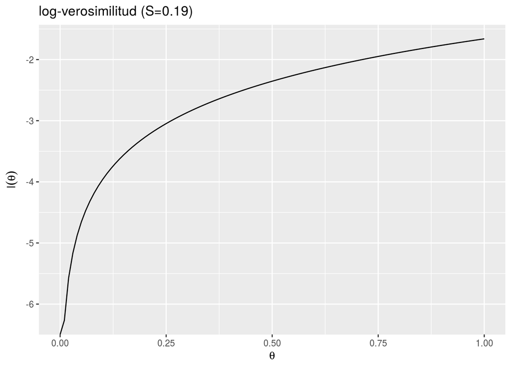

```r
l_bayes<-function(S){
  function(theta){
    log(theta)+log(S)
  }
}

xy <- data.frame(x = 0:1, y = 0:1)

log_verosimilitud <- ggplot(xy, aes(x = x, y = y)) +
    stat_function(fun = l_bayes(S = .19))+
    xlab(expression(theta)) +
    ylab(expression(l(theta))) +
    ggtitle("log-verosimilitud (S=0.19)")

log_verosimilitud
```